# PS1: Stationary Transformations

### GDPUSA

For GDPUSA, we notice a linear trend in the data. To remove it, we will take the first-difference.

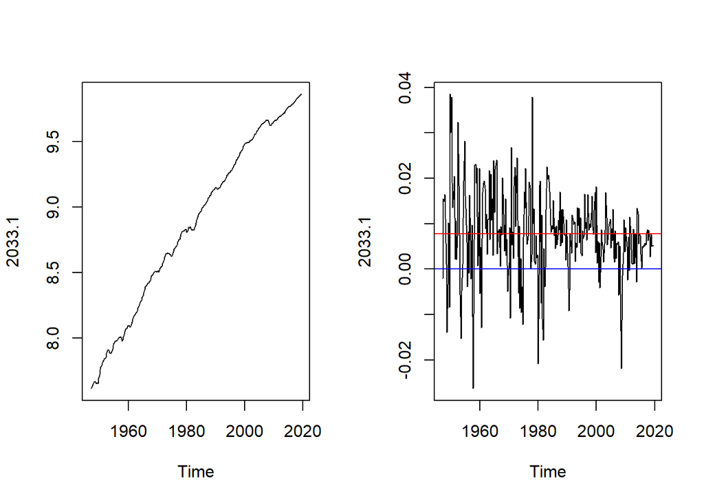

```r
par(mfrow=c(1,2))
# Base plot: GDPUSA
plot(ln.GDPUSA)
# 1st-diff plot
d1.lnGDPUSA <- diff(ln.GDPUSA)
plot(d1.lnGDPUSA)
abline(h=0, col="blue")
abline(h=mean(d1.lnGDPUSA), col="red")
```

```r
par(mfrow=c(1,1))
```

Again, we check the variance to see what differencing step to stop at.

```r
paste("Variance at 1st-diff: ", as.numeric(var(d1.lnGDPUSA))) # 1st-diff
```

```
[1] "Variance at 1st-diff:  8.61818132005271e-05"
```

```r
paste("Variance at 2nd-diff: ", as.numeric(var(diff(d1.lnGDPUSA)))) #2nd-diff
```

```
[1] "Variance at 2nd-diff:  0.000110848339456496"
```

Since variance increases at step 2, we stop after our first-difference and declare the data as stationary and ready to use.

### GDPUSAvar

We notice a somewhat constant trend, however it seems to still linearly trend upward slightly until 2000, then decrease sharply, increase linearly again, remain constant, etc. So we will take a first-difference to remove any trends.

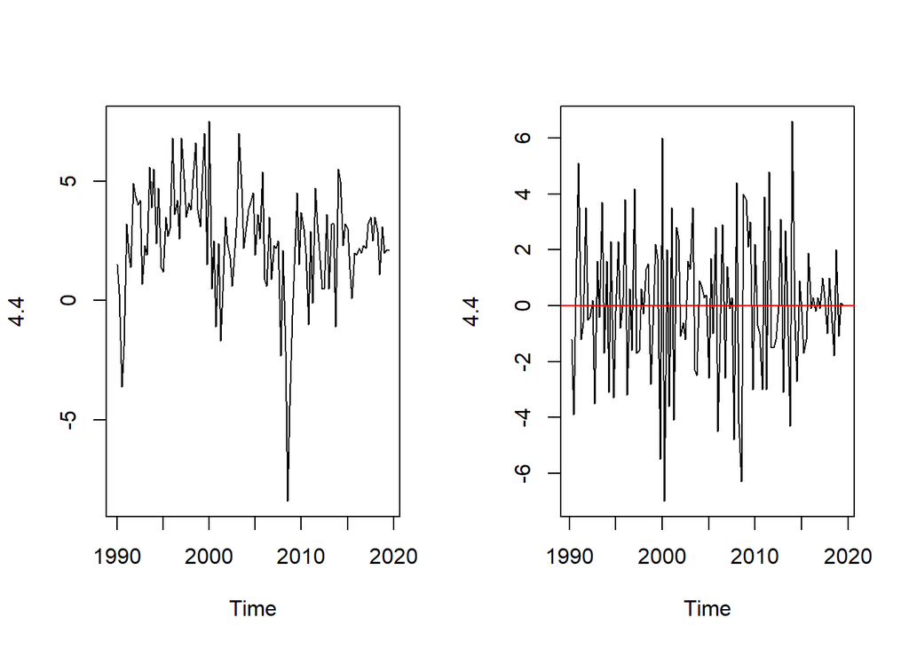

```r
par(mfrow=c(1,2))
# Base plot
plot(GDPUSAvar)
d1.GDPUSAvar <- diff(GDPUSAvar)
plot(d1.GDPUSAvar)
abline(h=0, col = "blue")
abline(h=mean(d1.GDPUSAvar), col = "red")
```

```r
par(mfrow=c(1,1))
```

Now we check the variance at each iteration and find out which step to stop at.

```r
paste("Variance at 1st-diff: ", as.numeric(var(d1.GDPUSAvar))) # 1st-diff
```

```
[1] "Variance at 1st-diff:  6.82749529190207"
```

```r
paste("Variance at 2nd-diff: ", as.numeric(var(diff(d1.GDPUSAvar)))) #2nd-diff
```

```
[1] "Variance at 2nd-diff:  19.9550663129973"
```

Variance increases at step 2, so we stop after our first-difference at step 1.

### EURDOL

We notice a decreasing linear trend until ~2001, then linearly increasing until ~2008, after which it is linearly decreasing until ~2016. Thus, we need to take first-differences to remove the trend from the data.

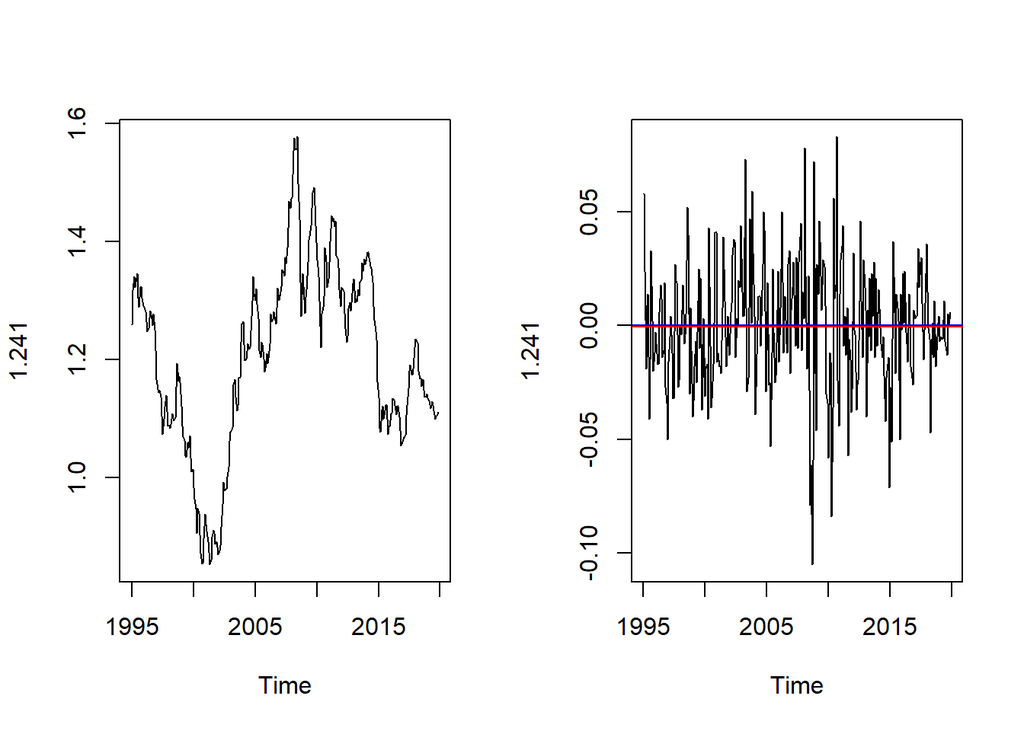

```r
par(mfrow=c(1,2))
# Base plot
plot(EURDOL)
d1.EURDOL <- diff(EURDOL)
# First-diff plot
plot(d1.EURDOL)
abline(h=0, col="blue")
abline(h=mean(d1.EURDOL), col="red")
```

```r
par(mfrow=c(1,1))
```

```r
paste("Variance at 1st-diff: ", as.numeric(var(d1.EURDOL))) # 1st-diff
```

```
[1] "Variance at 1st-diff:  0.000742473052674394"
```

```r
paste("Variance at 2nd-diff: ", as.numeric(var(diff(d1.EURDOL)))) #2nd-diff
```

```
[1] "Variance at 2nd-diff:  0.001038475998726"
```

Since the variance increases at step 2, we do not iterative past the first step; thus, our data becomes stationary and is ready to use.

## Final Checks

Using ACF Function we can check out plots to make sure our transformed time series are stationary.

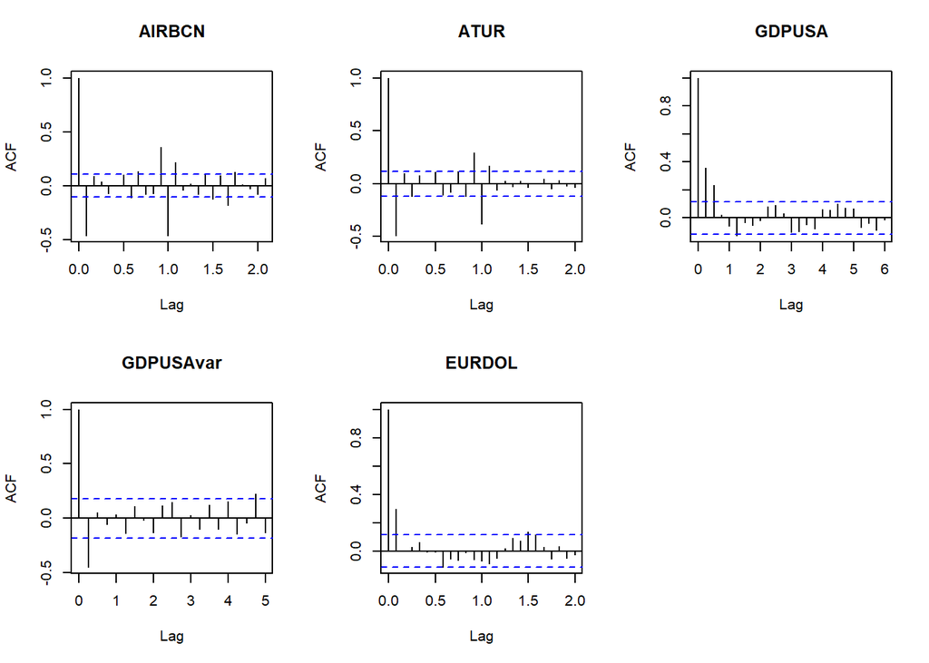

```r
par(mfrow=c(2,3))
acf(d1.d12.lnAIRBCN,
    main = "AIRBCN") # AIRBCN
acf(d2.d12.Atur,
    main = "ATUR") # ATUR
acf(d1.lnGDPUSA,
    main = "GDPUSA") # GDPUSA
acf(d1.GDPUSAvar,
    main = "GDPUSAvar") # GDPUSAvar
acf(d1.EURDOL,
    main = "EURDOL") # EURDOL
par(mfrow=c(1,1))
```

Since the ACF drops almost instantly and most of the values are contained between the confidence intervals, we can confirm our five time series objects are now stationary.

Back to top